# Deducing pancreatic cancer cell-intrinsic factors underlying heterogeneity of immune response via transcriptomics data

Bushangqing Liu - TidyBiology Final

My research is to investigate the potential mechanisms by which pancreatic cancers make tumor microenvironment immunosuppressive. This study is inspired from the published paper from [Dr. Ben Stanger](https://pubmed.ncbi.nlm.nih.gov/29958801/), where they generated a library of congenic tumor cell clones from mice that recapitulate the immune heterogeneity of pancreatic cancer.

By assessing T cell infiltration in each tumor cell clone, clones can be categorized into ‘High immunosuppressive’ and ‘Low immunosuppressive’ group. Here we have *A*, *B* and *C* cell clones that come from ‘High immunosuppressive’ group and *D*, *E* and *F* come from ‘Low immunosuppressive’ group. This study performed bulk RNA-seq for each cell clone and inferred transcriptomics differences that potentially contribute to heterogeneity of immune phenotype.

```r
library(tidyverse)
library(ggrepel)
countdata <- read.csv('low vs high.txt', header = T, sep = '\t')
```

First, let’s have a glance at the data

```r
#See how many columns do I have and how many genes are there
dim(countdata)
```

```
## [1] 24264    22
```

```r
#Take a look at what are these columns and the values
glimpse(countdata)
```

```
## Rows: 24,264
## Columns: 22
## $ Gene_symbol    <chr> "0610005C13Rik", "0610009B22Rik", "0610009E02Rik", "061…
## $ log2FoldChange <dbl> -1.10946741, -0.05105605, 0.39822313, -0.27758697, 0.02…
## $ pvalue         <dbl> 0.098139672, 0.783149486, 0.473690591, 0.456429151, 0.8…
## $ padj           <dbl> 0.37236658, 0.93196054, 0.77695592, 0.76568177, 0.94990…
## $ A1             <dbl> 2.9402165, 256.7789118, 4.9003609, 11.7608662, 997.7134…
## $ A2             <dbl> 1.007469, 240.784985, 3.022406, 11.082154, 1014.520836,…
## $ A3             <dbl> 0.7946475, 243.1621276, 3.1785899, 7.9464748, 937.68402…
## $ B1             <dbl> 0.000000, 392.931121, 7.187764, 2.395921, 1274.630223, …
## $ B2             <dbl> 2.750717, 388.768049, 13.753587, 9.169058, 1223.152305,…
## $ B3             <dbl> 1.7037014, 379.0735712, 5.9629551, 14.4814623, 1256.479…
## $ C1             <dbl> 0.9109205, 209.5117060, 2.7327614, 4.5546023, 934.60439…
## $ C2             <dbl> 0.0000000, 205.9490811, 6.4611476, 6.4611476, 955.44220…
## $ C3             <dbl> 4.065002, 169.713838, 5.081253, 2.032501, 1034.543037, …
## $ D1             <dbl> 1.153697, 409.562361, 9.229574, 13.844361, 909.113071, …
## $ D2             <dbl> 5.103077, 241.120410, 11.481924, 5.103077, 958.102793, …
## $ D3             <dbl> 1.039831, 192.368753, 6.238987, 4.159324, 1085.583667, …
## $ E1             <dbl> 5.202760, 298.291559, 0.000000, 11.272646, 849.784091, …
## $ E2             <dbl> 5.137263, 306.180860, 3.082358, 10.274525, 854.840521, …
## $ E3             <dbl> 1.002090, 226.472288, 0.000000, 13.027167, 879.834818, …
## $ F1             <dbl> 6.713572, 270.780723, 4.475714, 8.951429, 1328.168256, …
## $ F2             <dbl> 1.065120, 303.559256, 2.130240, 11.716322, 1318.618804,…
## $ F3             <dbl> 3.9610208, 326.7842168, 3.9610208, 6.9317864, 1276.4389…
```

```r
#What type of my data is (should be data.frame)
class(countdata)
```

```
## [1] "data.frame"
```

```r
#What about the type of data for 'Gene_symbol' and 'Log2FoldChange'
class(countdata$Gene_symbol)
```

```
## [1] "character"
```

```r
class(countdata$log2FoldChange)
```

```
## [1] "numeric"
```

Then, I will calculate the -1og10 value for p-value and save them into another new argument called ‘P’

```r
countdata <- countdata %>%
  mutate(P=-log10(pvalue))
```

Moreover, I will categorize genes into ‘UP’, ‘DOWN’ and ‘STABLE’, this grouping will be saved into a new argument called ‘category’

```r
countdata$category = ifelse(countdata$pvalue > 0.05,'STABLE',
                            ifelse(countdata$log2FoldChange>1,'UP',
                                   ifelse(countdata$log2FoldChange < -1,'DOWN',
                                          'STABLE')))
```

Now, I want to see the list of genes that are upregulated in ‘High immunosuppressive’ clones and whose log2FoldChange is greater than 7

```r
countdata %>%
  select(Gene_symbol, log2FoldChange, category) %>%
  filter(countdata$category == 'UP' & log2FoldChange > 7) %>%
  arrange(log2FoldChange)
```

```
##   Gene_symbol log2FoldChange category
## 1       Cspg4       7.151823       UP
## 2      Kcnk10       7.340314       UP
## 3       Rhox5       7.544788       UP
## 4       Trib2       7.586901       UP
## 5        Bnc1       7.856320       UP
## 6      Tm4sf5       8.535331       UP
## 7       Lrrk2       9.016604       UP
## 8       Pcdh7       9.472695       UP
## 9         Wt1      10.475172       UP
```

Take a look at how many genes are upregulated and downregulated

```r
countdata %>%
  group_by(category) %>%
  summarise(count = n())
```

```
## # A tibble: 3 × 2
##   category count
##   <chr>    <int>
## 1 DOWN       589
## 2 STABLE   23014
## 3 UP         661
```

Make new dataframe that contains genes that are marked ‘UP’ and ‘DOWN’

```r
upanddown <- countdata %>%
  filter(category %in% c('UP','DOWN'))
```

Make volcano plot using ‘ggplot’ function

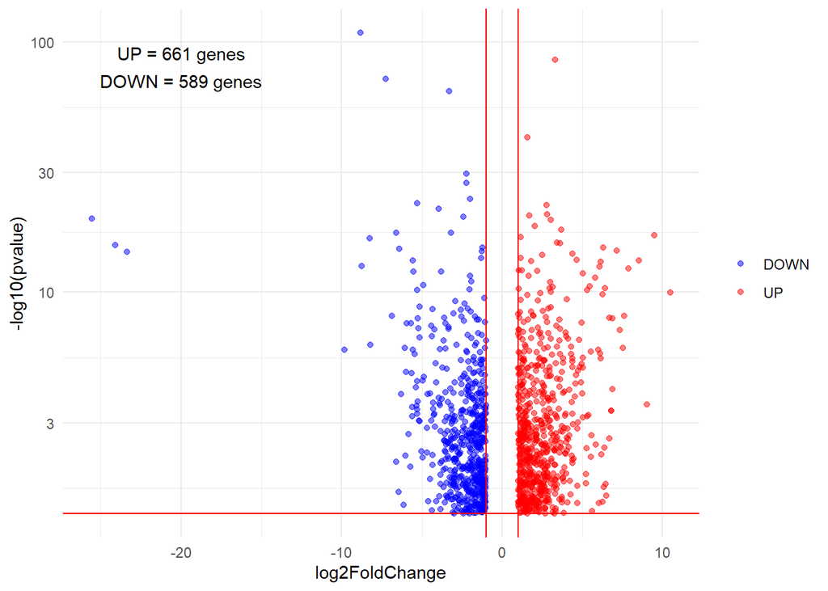

```r
#define color with each category
mycolors <- c('blue','red')
names(mycolors) <- c('DOWN','UP')

ggplot(data = upanddown, aes(x = log2FoldChange, y = P, col = category)) +
  geom_point(alpha = 0.5) +
  theme_minimal() +
  geom_vline(xintercept = c(-1,1), col='red') +
  geom_hline(yintercept = -log10(0.05), col='red') +
  scale_color_manual(values = mycolors) + guides(col = guide_legend(title = NULL)) +
  xlab('log2FoldChange') + ylab('-log10(pvalue)') +
  annotate('text', x = -20, y = 90, label = 'UP = 661 genes') +
  annotate('text', x = -20, y = 70, label = 'DOWN = 589 genes') +
  scale_y_log10()
```

Now I want to take a look at how many immune-relevant cytokine and chemokine ligands/receptors that are up/downregulated

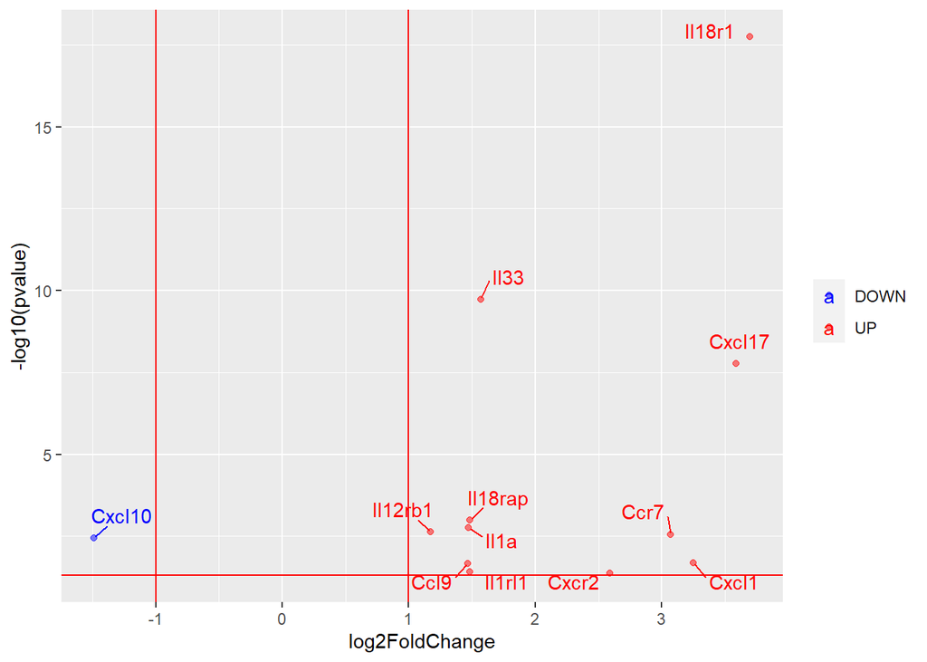

```r
#First I need to extract upregulated/downregulated genes from Interleukin family, CXC family and CCL family of chemokines
immune <- upanddown %>%
  filter(str_detect(Gene_symbol,'^(Il|Cxc|Ccl|Ccr)'))

ggplot(data = immune, aes(x = log2FoldChange, y = P, col = category, label = Gene_symbol)) +
  geom_point(alpha = 0.5) +
  geom_text_repel(aes(label = Gene_symbol), box.padding = 0.5) +
  geom_vline(xintercept = c(-1,1), col='red') +
  geom_hline(yintercept = -log10(0.05), col='red') +
  scale_color_manual(values = mycolors) + guides(col = guide_legend(title = NULL)) +
  xlab('log2FoldChange') + ylab('-log10(pvalue)')
```